# Simulation study of the ZINB model

I wrote two functions to simulate data :

- sim.make.matrices functions in a similar way as zinb.make.matrices and compute logM, logitPi and logtheta from model matrices which are provided as its arguments
- simulateNB takes as argument model matrices and simulate a dataset, parallelized to simulate large data more rapidly. The number of genes and cells being determined automatically from sizes of the provided design matrices.

A small test of function simulating the data:

```r
source("../R/functions_sim.R")
source("../R/functions_jp.R")

# number of cells
n=10

# number of genes
J=10

# define U, V, W and logtheta
U <- matrix(rep(2,n),ncol=1)
V <- matrix(rep(1,J),nrow=1)
W <- matrix(rep(1,J),nrow=1)
# no overdispersion : logtheta = 0
logtheta <- matrix( rep ( 0 , n*J ) , ncol = J , nrow = n )

# run the function simulateNB which simulates data from given model matrices
test.simulation <- simulateNB( U = U , V = V , W = W , offset.theta = logtheta )

print(test.simulation$counts)
```

```
##       [,1] [,2] [,3] [,4] [,5] [,6] [,7] [,8] [,9] [,10]
##  [1,]   14    1    0    0    3    0    0    0    4     0
##  [2,]    0    0    2   12    0    0    0    0    0     0
##  [3,]    0    0    0    0    0    0    0    0    0     0
##  [4,]    0    0    0    0    0   12    0    0    0     0
##  [5,]    0    0    0    0    0    0    0    0    0     0
##  [6,]    0    0    0    0    0    0    3    0    0     0
##  [7,]    0    0   11    0    0    0    9    0    0     0
##  [8,]    0    0    0    0    0    0    0    0    0     0
##  [9,]    0    0    0    0    0    0    0    0    0     0
## [10,]    0    0    1    0    0    7    0    0    0     3
```

```r
print(test.simulation$data.nb)
```

```
##       [,1] [,2] [,3] [,4] [,5] [,6] [,7] [,8] [,9] [,10]
##  [1,]   14    1   21   12    3   22    8    5    4    27
##  [2,]    0    1    2   12    3    5    5    9    5     4
##  [3,]    1   22    0    2    4    2    9    5   42     1
##  [4,]   15    5    3    9    0   12   10   23    8    10
##  [5,]    5    3    0    6   12   16    5   14    0     1
##  [6,]   13    0    1    7    1    0    3    4    0     0
##  [7,]    0   10   11    5    4    4    9   12   24     6
##  [8,]   21    5   15    0    1   12    3    3    0     4
##  [9,]    2    1   19    0    2    5   11   12    7     2
## [10,]    2    1    1    2    3    7    0    4    1     3
```

```r
print(test.simulation$dropouts)
```

```
##       [,1] [,2] [,3] [,4] [,5] [,6] [,7] [,8] [,9] [,10]
##  [1,]    0    0    1    1    0    1    1    1    0     1
##  [2,]    1    1    0    0    1    1    1    1    1     1
##  [3,]    1    1    0    1    1    1    1    1    1     1
##  [4,]    1    1    1    1    1    0    1    1    1     1
##  [5,]    1    1    1    1    1    1    1    1    1     1
##  [6,]    1    1    1    1    1    1    0    1    1     1
##  [7,]    1    1    0    1    1    1    0    1    1     1
##  [8,]    1    1    1    1    1    1    1    1    1     1
##  [9,]    1    1    1    1    1    1    1    1    1     1
## [10,]    1    1    0    1    1    0    1    1    1     0
```

First configuration: 100 genes and 100 cells. Only U, V, W are non trivial matrices.

```r
# number of cells
n <- 100

# number of genes
J <- 100

# number of latent factors
k <- 2

# matrix of latent factors
U <- matrix( rep(0,n*k) , nrow = n , ncol = k )
```

### Most simple case: 2 types of cells

Define U matrix to have two groups of approx. equal size via a mixture of two gaussian

```r
# simulate group indicator
ind <- rbinom( n , size = 1 , prob=1/2 )

# simulate two components of mixture
U [ ind == 1 , ] <- t ( sapply ( seq ( sum(ind) ) ,
                    function (i) {abs (MASS::mvrnorm ( 1 , mu = c(2,4), Sigma = matrix ( c(1,0,0,1) , nrow=2 ) ) )} ))
U [ ind == 0 , ] <- t ( sapply ( seq ( sum(1-ind) ) , function(i) {abs (MASS::mvrnorm ( 1 , mu = c(6,8), Sigma = matrix ( c(1,0,0,1) , nrow=2 ) ) )} ) )


# define gene loadings V on columns of U
V <- matrix ( abs ( rnorm( n*k , mean = 1, sd = 1 ) ), nrow = 2 )/4

# define W matrix
W <- matrix ( rnorm( n*k , mean = -0.5, sd = 0.1 ) , nrow = 2 )

# dispersion parameter fixed between 1 and exp(1)
# logtheta <- matrix( rep ( runif(J), n) , ncol = J , byrow = TRUE )

# no overdispersion : logtheta = 0
logtheta <- matrix( rep(0,n*J) , ncol = J , byrow = TRUE )

# simulate data
simdata <- simulateNB ( U=U, V=V, W=W, offset.theta = logtheta )

# check if there are any zero columns
sum ( colSums(simdata$counts!=0) == 0 )
```

```
## [1] 0
```

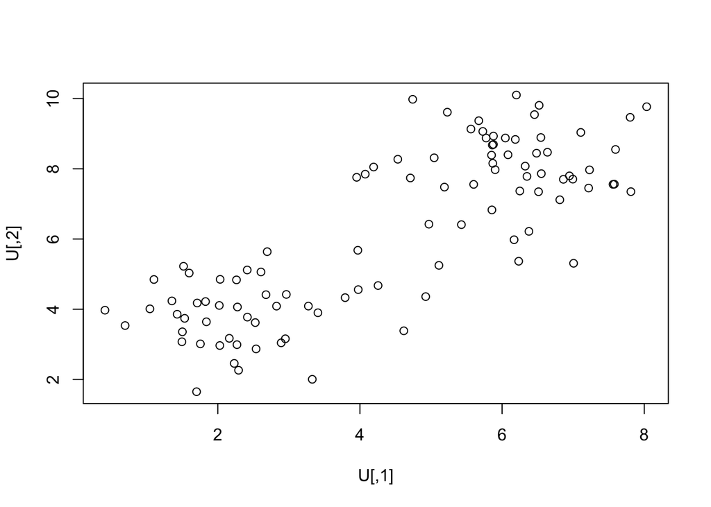

```r
# plot simulated groups
plot(U)
```

```r
print(simdata$zero.fraction)
```

```
## [1] 0.1339
```

Run zinb.PCA, zinb.PCA.theta (with known theta) and several values of penalty parameter

```r
simdata.zinb <- zinb.PCA (simdata$counts , no_cores=7 , alt.number=25 , verbose=FALSE)

simdata.zinb.theta.0.1 <- zinb.PCA.theta (simdata$counts , a.theta=rep(0,J), no_cores=7 , alt.number=25 , verbose=FALSE,epsilon=0.1)

simdata.zinb.theta.0.01 <- zinb.PCA.theta (simdata$counts , a.theta=rep(0,J), no_cores=7 , alt.number=25 , verbose=FALSE,epsilon=0.01)

simdata.zinb.theta.0.7 <- zinb.PCA.theta (simdata$counts , a.theta=rep(0,J), no_cores=7 , alt.number=25 , verbose=FALSE,epsilon=0.7)
```

Theta is actually overestimated. Here is the plot of estimated values:

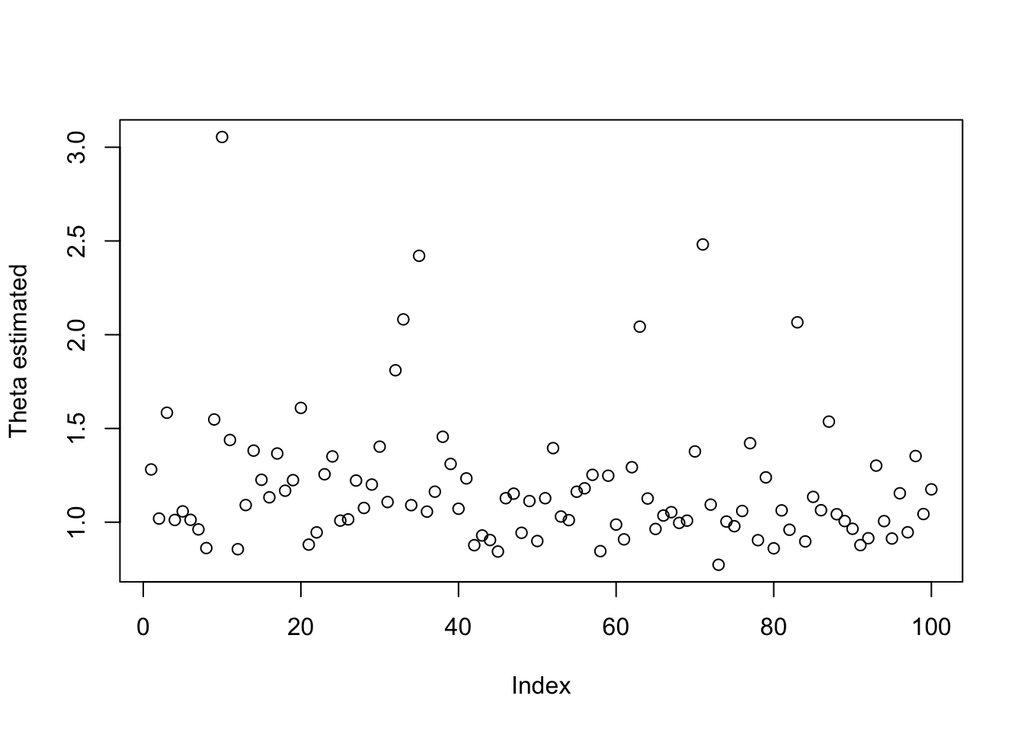

Now plot U times V and U times W for diffrent penalties (using known theta values).

- epsilon = 0.01

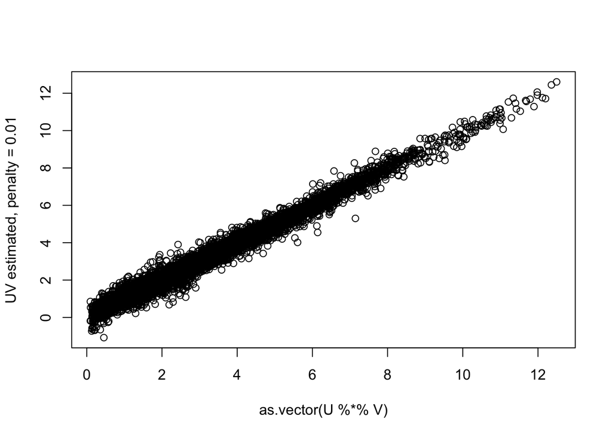

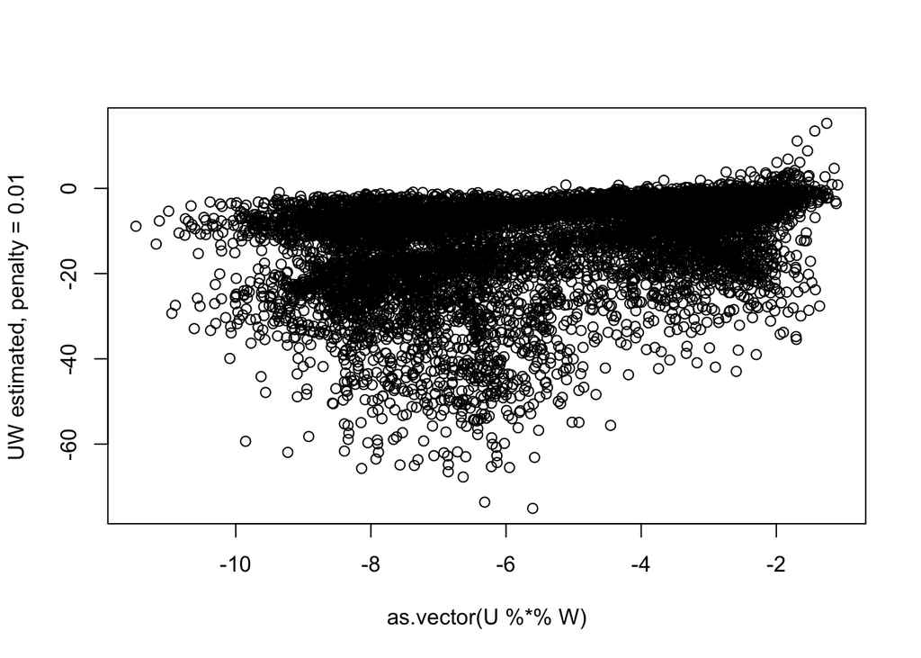

- epsilon = 0.1

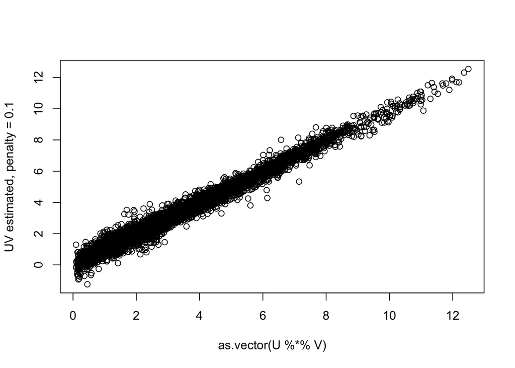

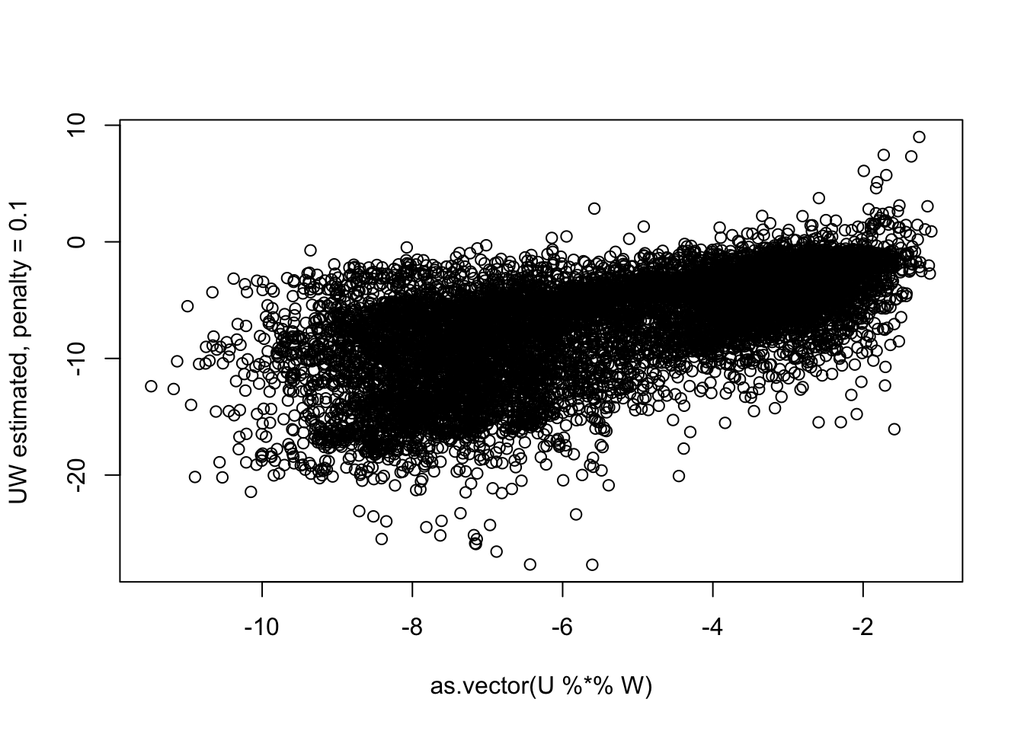

- epsilon = 0.7

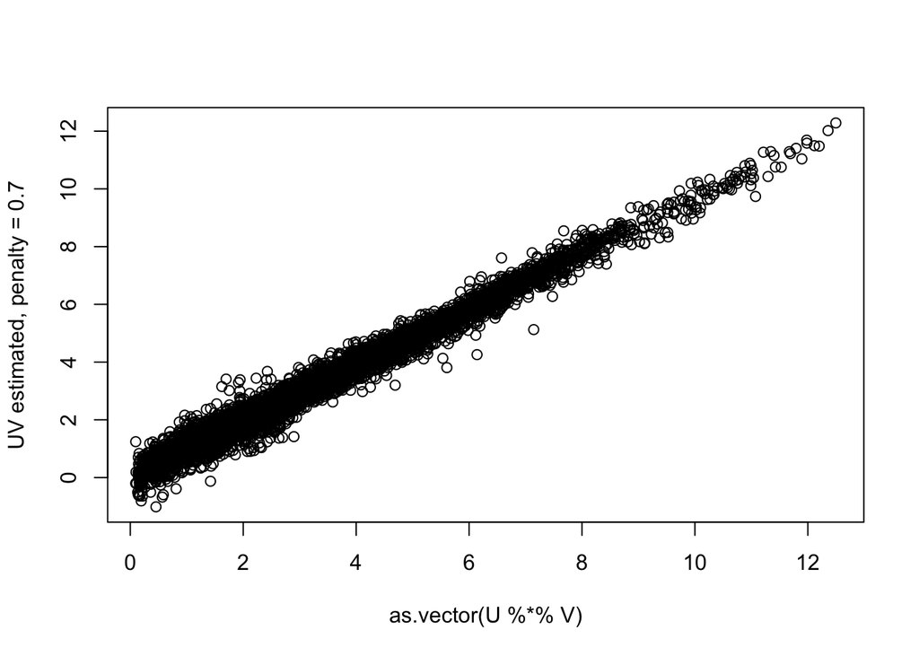

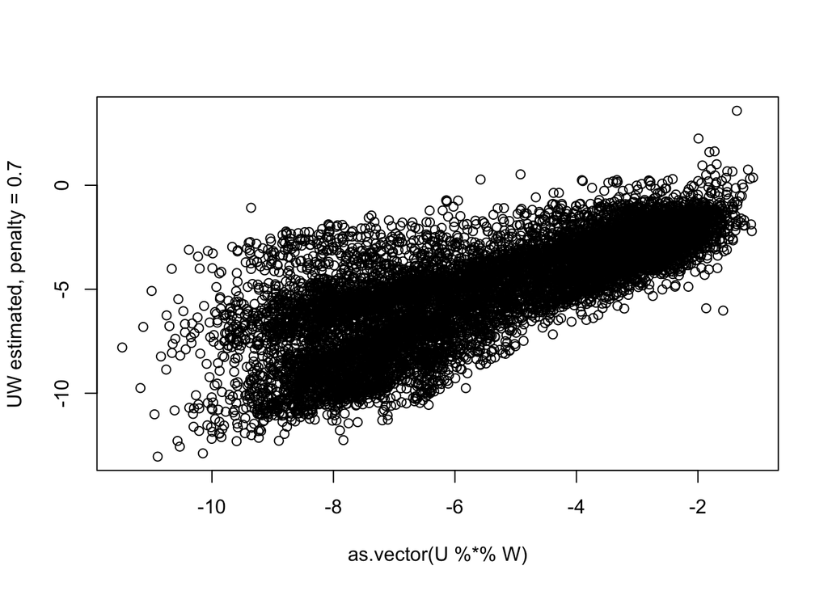

And finally let us keep the unknown theta, but we take high value of penalty :

```r
simdata.zinb.0.7 <- zinb.PCA (simdata$counts , no_cores=7 , alt.number=25 , verbose=FALSE,epsilon=0.7)
```

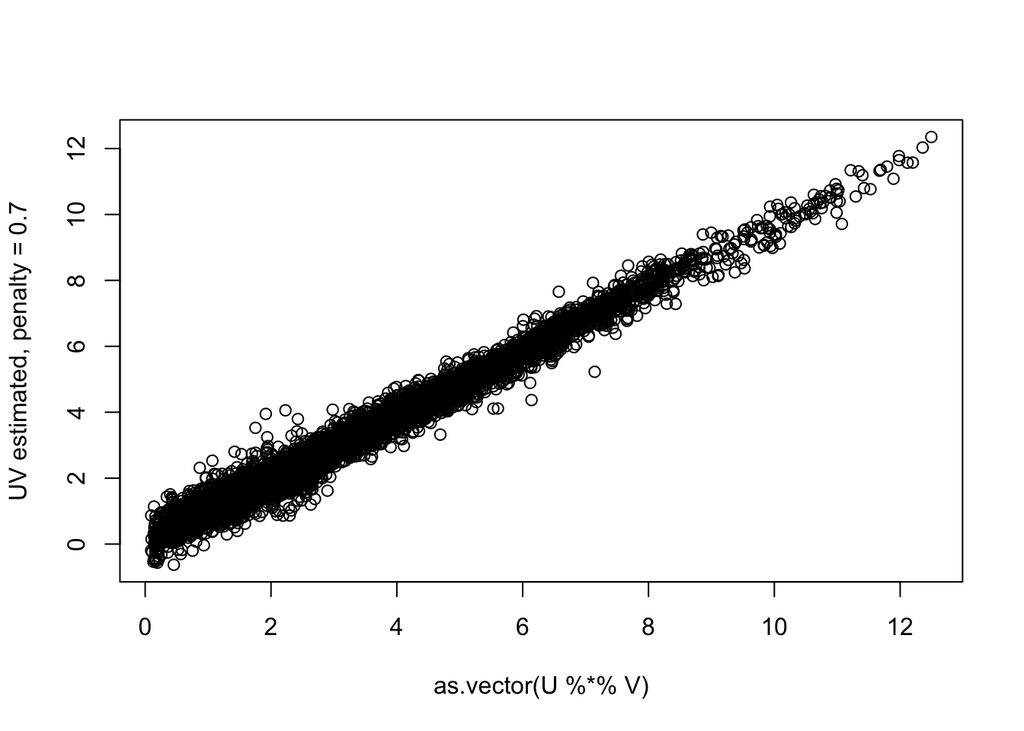

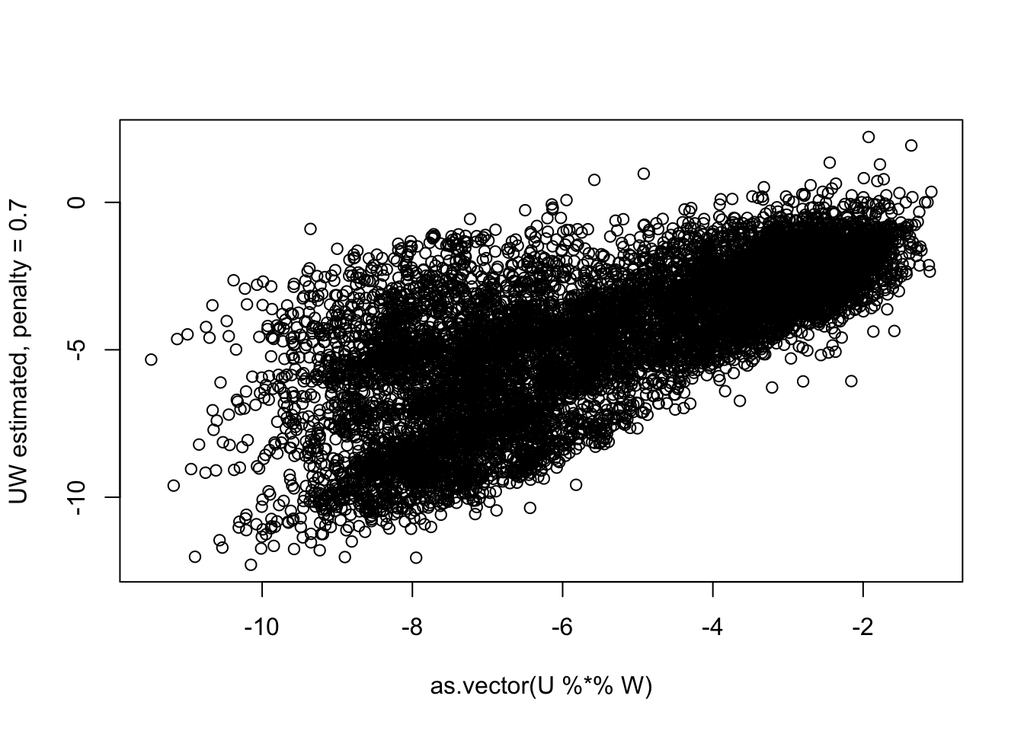

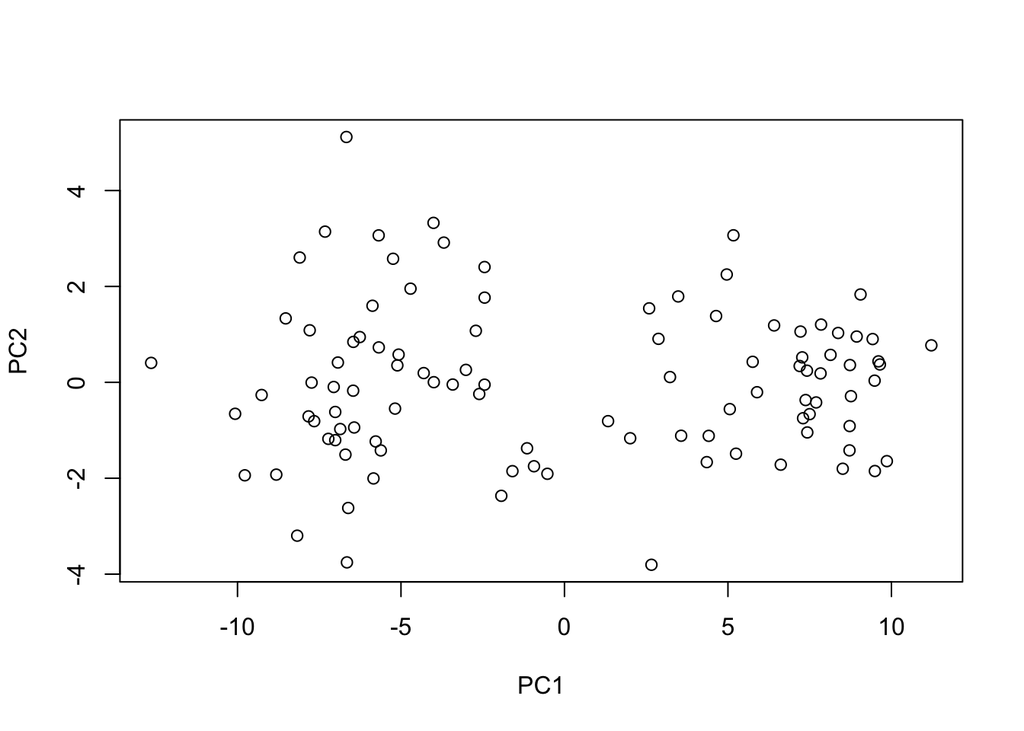

```r
# run pca
simdata.pca <- prcomp(log(1+simdata$counts), scale.=TRUE, center = TRUE)

#plot PCA
plot(simdata.pca$x[,1:2])
```

```r
#simdata.pca2 <- prcomp(U%*%V, scale.=TRUE, center = TRUE)
#plot(simdata.pca2$x[,1:2])
#plot(U%*%V,simdata.zinb$U%*%t(simdata.zinb$V))
```

Now apply kmeansruns : function from fpc package, includes several runs of kmeans and detection of the optimal number of clusters via the silhouette statistics

```r
# see $cluster for cluster labels, $centers for centers, $withinss for clusterwise within sum of squares,
# $size for numbers of points in clusters, $bestk for optimal number of clusters, $crit averaged silhouette
# for each nb of clusters which have been tested

kmeans.zinb <- fpc::kmeansruns ( data = simdata.zinb$U , krange = c(2:5) , criterion = "asw" )
kmeans.pca <- fpc::kmeansruns ( data = simdata.pca$x[,1:2] , krange = c(2:5) , criterion = "asw" )
print(c(kmeans.zinb$bestk,kmeans.pca$bestk))
```

```
## [1] 2 2
```

```r
print(c(kmeans.zinb$withinss,kmeans.pca$withinss))
```

```
## [1] 193.6232 219.9480 347.2411 513.9267
```

```r
print(c(kmeans.zinb$crit,kmeans.pca$crit))
```

```
##  [1] 0.0000000 0.6866578 0.5061965 0.4097260 0.3926437 0.0000000 0.6906292
##  [8] 0.5216242 0.4418968 0.4370669
```

Decisions to take about the plan of simulations:

- Define and list all configurations which we want to simulate. Some suggestions:
  - 2 latent factors without known design matrix (PCA case)
  - Should we consider more than 2 factors? Do we have a solution to choose the nb of factors?
  - Case of different library sizes ? Our way to normalize versus Deseq?
  - Any others?
- Number of datasets to simulate for each configuration. Suggestion:
  - 50 datasets
- Number of genes, number of cells :
  - reasonable values?
  - one or several configuration per simulated case?
- Zero inflation
  - Should we consider the case of no zero inflation?
  - Which configurations of zero inflation we consider?
    - Several proportions of zeros: which ones?
- Define a list of methods to compare with :
  - ZIFA
  - PCA
  - Weighted PCA
  - Any others ? Should we compare to non linear methods:
    - Kernel PCA
    - Isomap
    - Maximum Variance Unfolding
    - Diffusion Maps
    - Locally Linear Embedding
    - Laplacian Eigenmaps
- Define criteria of comparison :
  - Error of reconstruction of M matrix? Error of reconstruction of Pi matrix?
  - General measures of quality of dimension reduction ? (without notion of clusters)
  - Dimension reduction + clustering. Suggestions:
    - For each method, do a dimension reduction followed by k-means, including the choice of number of clusters.
      1. Case of simulation with a known reference partition: compare Rand indices of similarity with ref
      2. General statistics on quality of clustering. Which ones? Package fpc, function cluster.stats provides:
         - Vector of clusterwise within cluster distance medians
         - Vector of cluster diameters
         - Vector of clusterwise minimum distances of a point in the cluster to a point of another cluster
         - Vector of clusterwise average distances of a point in the cluster to the points of other clusters
         - Matrix of separation values between all pairs of clusters
         - Matrix of mean dissimilarities between points of every pair of clusters
         - Average distance between clusters
         - Average distance within clusters
         - A generalisation of the within clusters sum of squares (k-means objective function)
         - Vector of cluster average silhouette widths
         - Average silhouette width
         - Silhouette averaged over all observations ( any better solution using silhouette? )
         - Minimum average dissimilarity between two cluster / maximum average within cluster dissimilarity
         - Average.within/average.between